# Clinical Coding Changes over time

### OPCS-4 Codelag

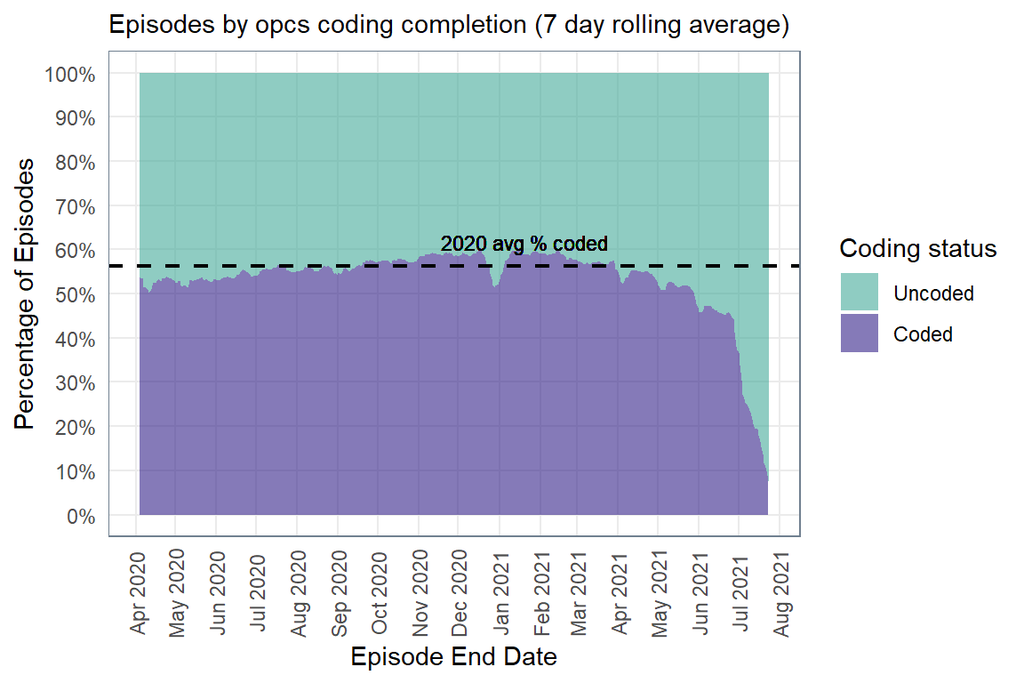

**Figure 30.** Episodes by coding completion (7 day rolling average)

The below chart shows the number of episodes ending on a given day which had an OPCS-4 operation code recorded. The area shading indicates the first data extract in which an OPCS-4 coding was recorded.

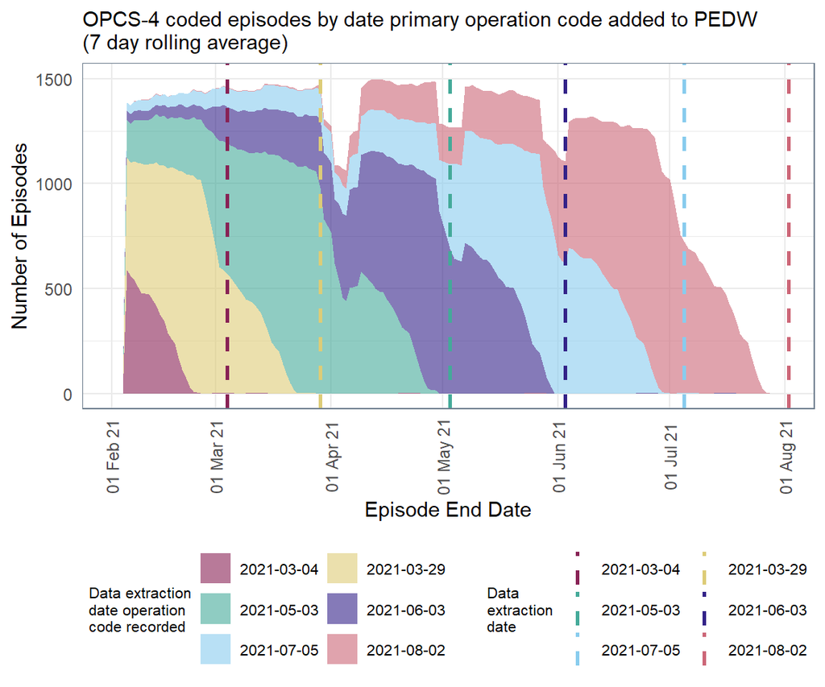

**Figure 31.** OPCS-4 coded episodes by date primary operation code added to PEDW (7 day rolling average)

The below chart shows the percentage of all episodes ending on a given day which had an OPCS-4 operation code recorded. The area shading indicates the first data extract in which an OPCS-4 coding was recorded.

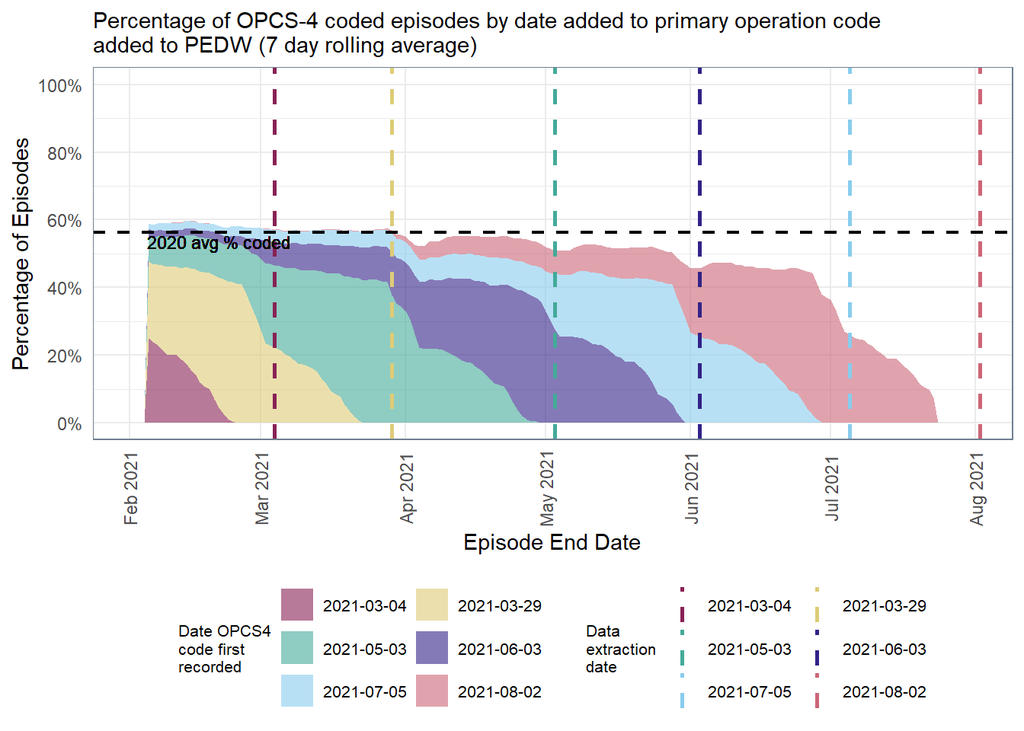

**Figure 32.** Percentage of OPCS-4 coded episodes by date added to PEDW (7 day rolling average)

The below charts show the number of OPCS-4 coded episodes ending on a given day, displayed by OPCS-4 Chapter. The area shading indicates the first data extract in which an OPCS-4 code was recorded.

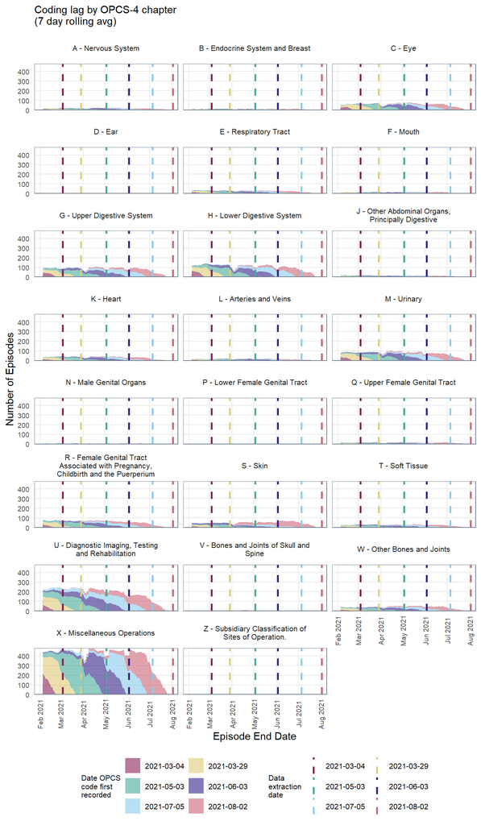

**Figure 33.** Coding lag by OPCS-4 Chapter (7 day rolling avg)

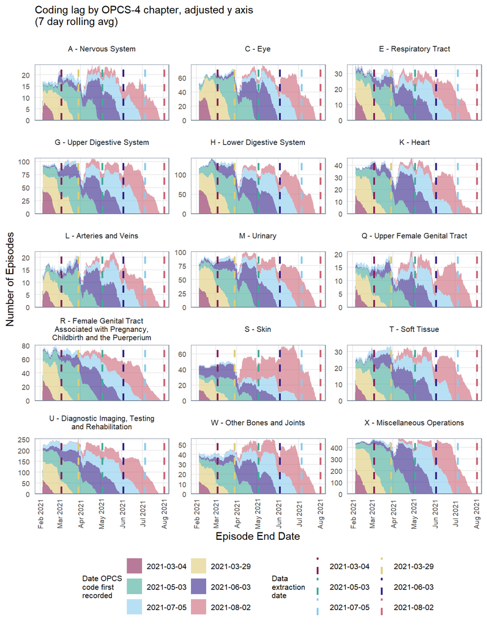

**Figure 34.** Coding lag by OPCS-4 Chapter, adjusted y-axis (7 day rolling avg)

### Analysis by Service Provision

It is recognised that COVID-19 will have resulted in changes to the usual services hospitals provide. The below chart shows the differences in elective, emergency and other admissions.

Elective episodes saw a more than 50% reduction between April and December 2020, compared to 2019.

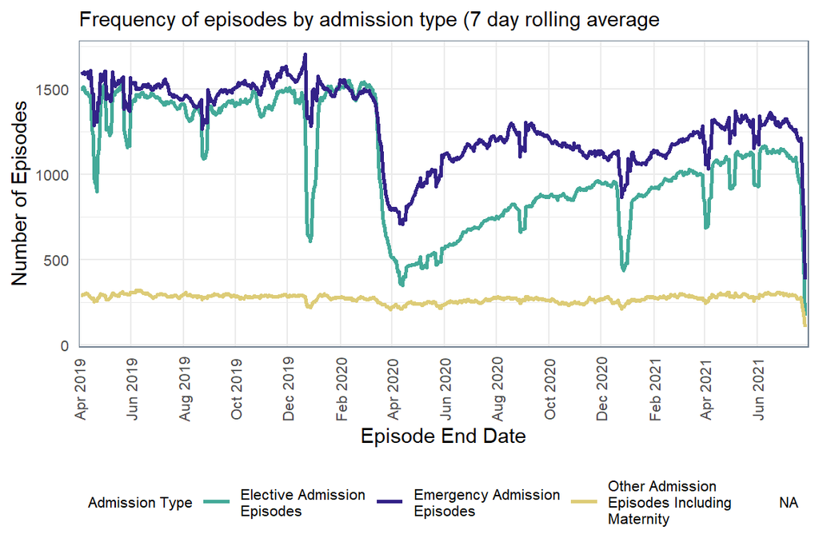

**Figure 37.** Frequency of episodes by admission type, 7 day rolling average

**Table 7:** Average episodes per month by admission type, Apr19 to Mar20 comparison with Apr20 to Mar21

| Admission group | 19/20 mean eps. | 20/21 mean eps. | Percentage change |
| --- | --- | --- | --- |
| Elective Admission Episodes | 41681 | 23564 | -43% |
| Emergency Admission Episodes | 45046 | 33908 | -25% |
| Other Admission Episodes Including Maternity | 8603 | 7887 | -8% |

## References

Audit Wales (2020). Cracking the Code, Management of Clinical Coding Across Wales (Sep 2020). Available at: https://www.audit.wales/sites/default/files/clinical_coding_eng_10.pdf. Accessed: 11/05/21.

BMA (2020), The Hidden Impact of Covid. Available at: bma.org.uk/media/2841/the-hidden-impact-of-covid_web-pdf.pdf. Accessed 11/05/21.

HSCIC (last updated April 2021), Covid-19 National Clinical Standard and Guidance. Available at: hscic.kahootz.com/connect.ti/t_c_home/view?objectID=19165328. Accessed: 11/05/21.

World Health Organisation (2021). Coronavirus symptoms. Available at: who.int/health-topics/coronavisurs#tab=tab_3. Accessed 11/05/21.

## Appendices

Appendix 1: Table 8. ICD-10 Chapter Codes and Descriptions

| CHAPTER_NUMBER | CHAPTER_DESCRIPTION |
| --- | --- |
| 1 | Certain infectious and parasitic diseases |
| 2 | Neoplasms |
| 3 | Diseases of the blood and blood-forming organs and certain disorders involving the immune mechanism |
| 4 | Endocrine, nutritional and metabolic diseases |
| 5 | Mental and behavioural disorders |
| 6 | Diseases of the nervous system |
| 7 | Diseases of the eye and adnexa |
| 8 | Diseases of the ear and mastoid process |
| 9 | Diseases of the circulatory system |
| 10 | Diseases of the respiratory system |
| 11 | Diseases of the digestive system |
| 12 | Diseases of the skin and subcutaneous tissue |
| 13 | Diseases of the musculoskeletal system and connective tissue |
| 14 | Diseases of the genitourinary system |
| 15 | Pregnancy, childbirth and the puerperium |
| 16 | Certain conditions originating in the perinatal period |
| 17 | Congenital malformations, deformations and chromosomal abnormalities |
| 18 | Symptoms, signs and abnormal clinical and laboratory findings, not elsewhere classified |
| 19 | Injury, poisoning and certain other consequences of external causes |
| 20 | External causes of morbidity and mortality |
| 21 | Factors influencing health status and contact with health services |
| 22 | Codes for special purposes |

Appendix 2: Table 9. Episodes recorded by ICD-10 category 1 description, Apr19 to Mar20 comparison with Apr20 to Mar21

| Category 1 Description | 19/20 Episodes | 20/21 Episodes | Percentage change |
| --- | --- | --- | --- |
| Diseases of middle ear and mastoid | 2548 | 551 | -78% |
| Other acute lower respiratory infections | 15800 | 3473 | -78% |
| Papulosquamous disorders | 9532 | 2113 | -78% |
| Nerve, nerve root and plexus disorders | 5277 | 1230 | -77% |
| Acute upper respiratory infections | 17680 | 4171 | -76% |
| Other congenital malformations | 544 | 131 | -76% |
| Disorders of ocular muscles, binocular movement, accommodation and refraction | 578 | 146 | -75% |
| Other diseases of upper respiratory tract | 5349 | 1358 | -75% |
| Arthropathies | 25296 | 6737 | -73% |
| Congenital malformations of eye, ear, face and neck | 290 | 86 | -70% |
| Disorders of lens | 20233 | 6094 | -70% |
| Dermatitis and eczema | 3461 | 1063 | -69% |
| Disorders of skin appendages | 2433 | 758 | -69% |
| Disorders of conjunctiva | 304 | 95 | -69% |
| Diseases of oral cavity, salivary glands and jaws | 7673 | 2399 | -69% |
| Disorders of eyelid, lacrimal system and orbit | 2896 | 995 | -66% |
| Other viral diseases | 10168 | 3499 | -66% |
| Persons with potential health hazards related to family and personal history and certain conditions influencing health status | 181 | 66 | -64% |
| Injuries to unspecified part of trunk, limb or body region | 110 | 42 | -62% |
| Radiation-related disorders of the skin and subcutaneous tissue | 612 | 247 | -60% |
| Certain zoonotic bacterial diseases | 17 | 7 | -59% |
| Viral infections characterized by skin and mucous membrane lesions | 1262 | 520 | -59% |
| Disorders of sclera, cornea, iris and ciliary body | 400 | 165 | -59% |
| Viral infections of the central nervous system | 276 | 118 | -57% |
| Hernia | 11564 | 5085 | -56% |
| Disorders of breast | 871 | 399 | -54% |
| Helminthiases | 52 | 24 | -54% |
| Chronic lower respiratory diseases | 20985 | 9873 | -53% |
| Noninflammatory disorders of female genital tract | 10106 | 4799 | -53% |
| Persons encountering health services for specific procedures and health care | 6248 | 2990 | -52% |

[output cut: 161 more lines]

Appendix 3: Table 10. OPCS-4 Chapter Codes and Descriptions

| OPER_INIT | Description |
| --- | --- |
| A | Nervous System |
| B | Endocrine System and Breast |
| C | Eye |
| D | Ear |
| E | Respiratory Tract |
| F | Mouth |
| G | Upper Digestive System |
| H | Lower Digestive System |
| J | Other Abdominal Organs, Principally Digestive |
| K | Heart |
| L | Arteries and Veins |
| M | Urinary |
| N | Male Genital Organs |
| P | Lower Female Genital Tract |
| Q | Upper Female Genital Tract |
| R | Female Genital Tract Associated with Pregnancy, Childbirth and the Puerperium |
| S | Skin |
| T | Soft Tissue |
| U | Diagnostic Imaging, Testing and Rehabilitation |
| V | Bones and Joints of Skull and Spine |
| W | Other Bones and Joints |
| X | Miscellaneous Operations |
| Y | Subsidiary Classification of Methods of Operation |
| Z | Subsidiary Classification of Sites of Operation. |

Note that any figures in the below chart which are less than five are shown as zero.

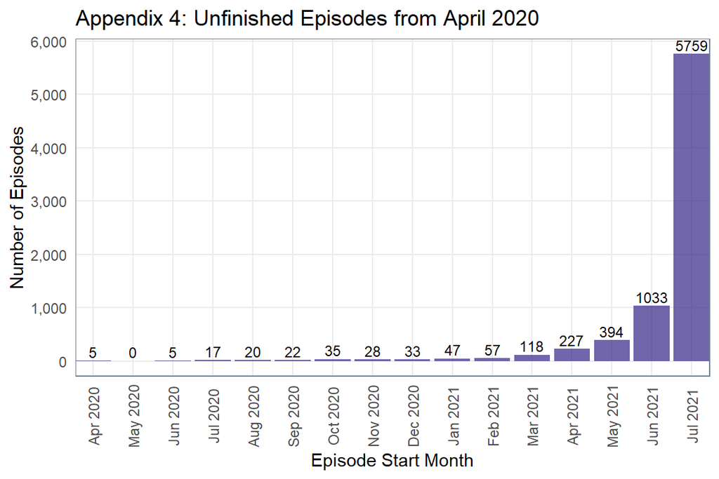

**Appendix 4:** figure 38. Unfinished PEDW episodes with episode start dates from April 2020

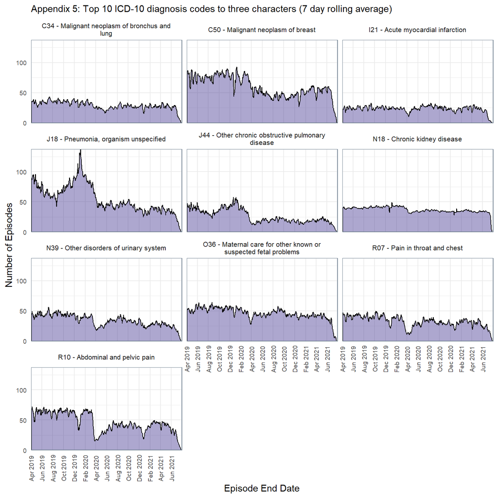

**Appendix 5:** figure 39. Top 10 recorded ICD-10 category 1 codes (to three characters), 7 day rolling average

Appendix 6: Table 11. Top 10 ICD-10 3 character operation codes

| 3 character ICD-10 code | Title |
| --- | --- |
| C50 | Malignant neoplasm of breast |
| J18 | Pneumonia, organism unspecified |
| R10 | Abdominal and pelvic pain |
| O36 | Maternal care for other known or suspected fetal problems |
| N39 | Other disorders of urinary system |
| R07 | Pain in throat and chest |
| C34 | Malignant neoplasm of bronchus and lung |
| J44 | Other chronic obstructive pulmonary disease |
| N18 | Chronic kidney disease |
| I21 | Acute myocardial infarction |

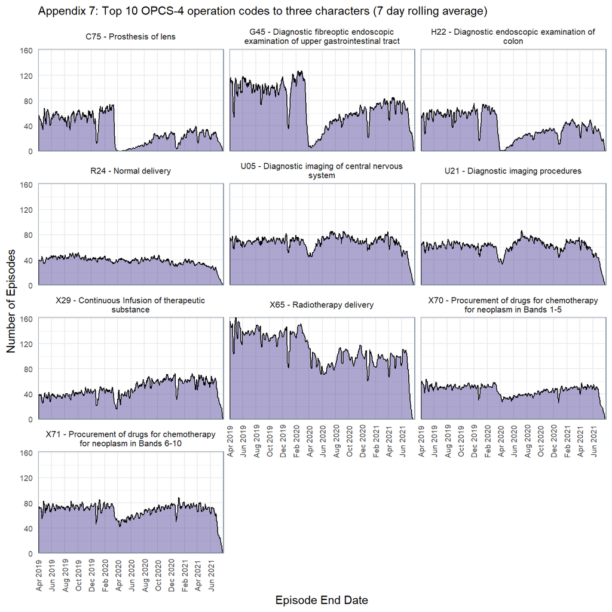

**Appendix 7:** figure 40. Top 10 recorded OPCS-4 codes (to three characters), 7 day rolling average

Appendix 8: Table 12. Top 10 OPCS-4 3 character operation codes

| 3 character OPCS code | Title |
| --- | --- |
| X65 | Radiotherapy delivery |
| G45 | Diagnostic fibreoptic endoscopic examination of upper gastrointestinal tract |
| U05 | Diagnostic imaging of central nervous system |
| X71 | Procurement of drugs for chemotherapy for neoplasm in Bands 6-10 |
| U21 | Diagnostic imaging procedures |
| X70 | Procurement of drugs for chemotherapy for neoplasm in Bands 1-5 |
| C75 | Prosthesis of lens |
| H22 | Diagnostic endoscopic examination of colon |
| R24 | Normal delivery |
| X29 | Continuous Infusion of therapeutic substance |

Appendix 9: Table 13. ALF status code descriptions

| ALF_STS_CD | ALF_STS_DESC |
| --- | --- |
| 1 | NHS Number passes check digit test |
| 2 | NHS Number derived through external linkage, i.e. CRN match on PEDW |
| 4 | Surname, First Name, Postcode, Date of Birth and Gender Code match exactly to WDS |
| 35 | Fuzzy Matching probability >= 0.5 & < 0.9 |
| 39 | Fuzzy Matching probability >= 0.9 |
| 99 | No match or Fuzzy Matching probability < 0.5 |